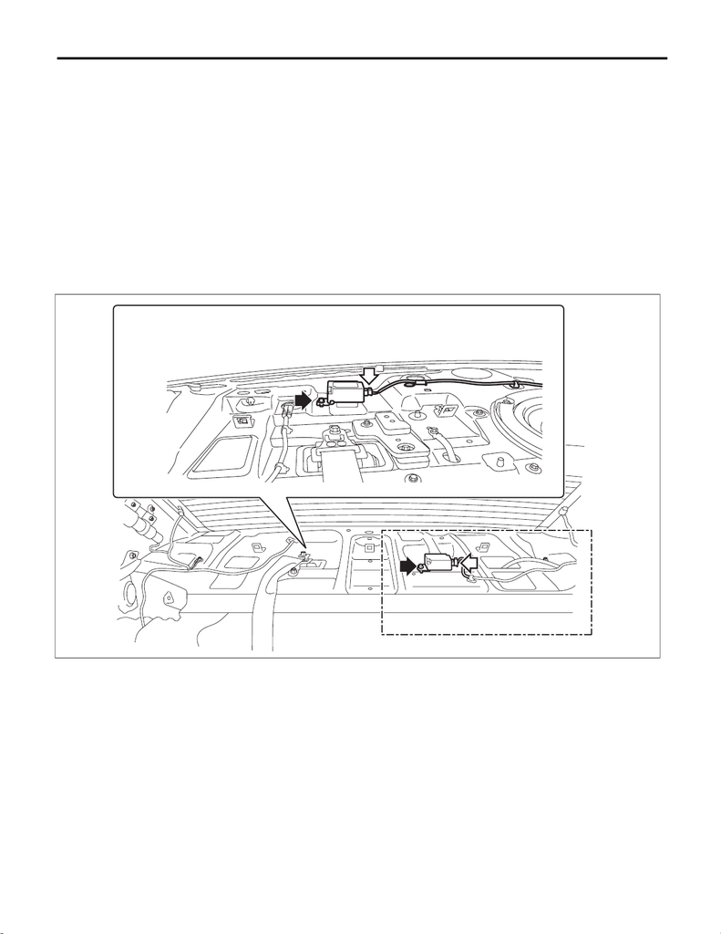

Receiver

SECURITY AND LOCKS

32.Receiver

A: REMOVAL

NOTE:

Except for model with keyless entry

1) Disconnect the ground cable from battery. <Ref. to NT-5, BATTERY, NOTE, Note.>

NOTE:

For models other than STI model, disconnect the ground terminal from battery sensor.

2) Remove the trim panel assembly - rear shelf. <Ref. to EI-92, REMOVAL, Rear Shelf Trim.>

3) Remove the receiver assembly.

(1) Disconnect the connector.

(2) Remove the bolt and remove the receiver assembly.

NOTE:

For models with power amplifier, installation position of the receiver assembly is different.

B: INSTALLATION

1) Install the receiver assembly.

Tightening torque:

13 N·m (1.3 kgf-m, 9.6 ft-lb)

2) Install the trim panel assembly - rear shelf.

3) Connect the battery ground terminal. <Ref. to NT-5, BATTERY, NOTE, Note.>

NOTE:

For models other than STI model, connect the ground terminal to battery sensor.

SL-02876

(A)

(B)

[figure not shown]

Receiver

SECURITY AND LOCKS

C: INSPECTION